*Reproducible Research: Week 2 Assignment*

**Loading and preprocessing the data**

1.Load the data

```r
setwd("~/DataScienceM5_ReproducibleResearch/DataScienceM5_Week2_PeerAssignment/repdata_data_activity")
activity<-read.csv("activity.csv")
```

2.Process/transform the data (if necessary) into a format suitable for your analysis

**What is mean total number of steps taken per day?**

1.Calculate the total number of steps taken per day

```r
Total_Steps_By_Day <-aggregate(steps~date, data=activity,sum, na.rm=TRUE)
#head(Total_Steps_By_Day)
```

2.Make a histogram of the total number of steps taken each day

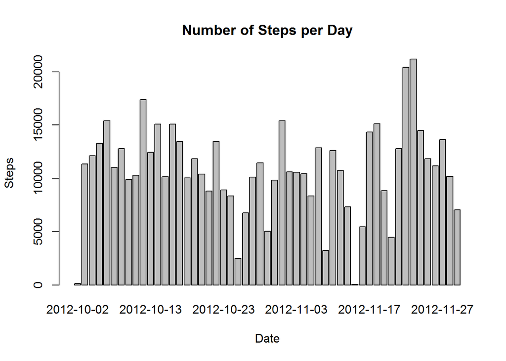

```r
  barplot(Total_Steps_By_Day$steps, names.arg =Total_Steps_By_Day$date, main="Number of Steps per Day",xlab="Date", ylab="Steps")
```

3(a)Calculate and report the mean number of steps taken per day

```r
mean(Total_Steps_By_Day$steps)
```

```
## [1] 10766.19
```

3(b)Calculate and report the median total of steps per day

```r
median(Total_Steps_By_Day$steps)
```

```
## [1] 10765
```

**What is the average daily activity pattern?**

1.Make a time series plot (i.e. type = “l”) of the 5-minute interval (x-axis) and the average number of steps taken, averaged across all days (y-axis)

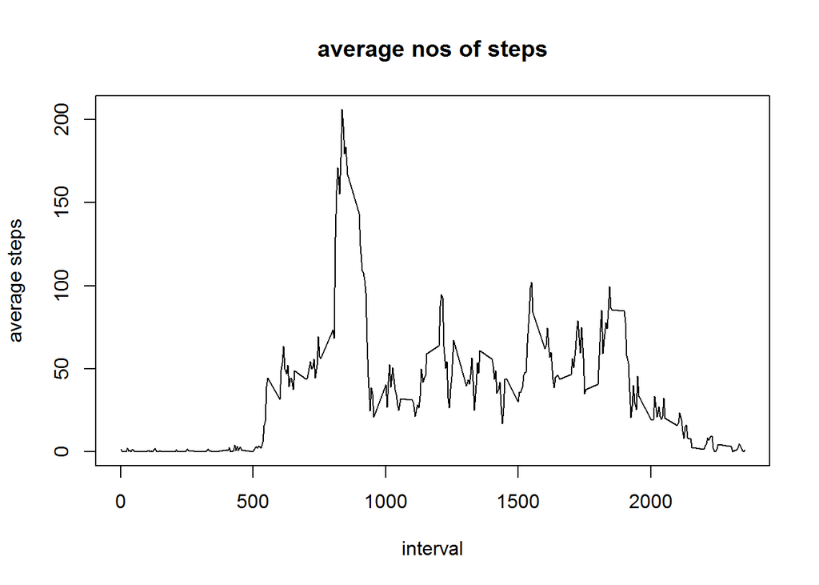

```r
activity<-read.csv("activity.csv", header=TRUE)
Average_Steps_By_Interval <-aggregate(steps~ interval, data=activity,mean, na.rm=TRUE)
plot(Average_Steps_By_Interval$interval, Average_Steps_By_Interval$steps, type="l",xlab="interval",ylab="average steps", main="average nos of steps")
```

2.Which 5-minute interval, on average across all the days in the dataset, contains the maximum number of steps?

```r
Average_Steps_By_Interval$interval[which.max(Average_Steps_By_Interval$steps)]
```

```
## [1] 835
```

**Imputing missing values**

Note that there are a number of days/intervals where there are missing values (coded as NA). The presence of missing days may introduce bias into some calculations or summaries of the data.

1.Calculate and report the total number of missing values in the dataset (i.e. the total number of rows with NAs)

```r
x<-(is.na(activity$steps))
numofna<-sum(x)
```

There are 2304 total number of row with NAS in the dataset.

Devise a strategy for filling in all of the missing values in the dataset. The strategy does not need to be sophisticated. For example, you could use the mean/median for that day, or the mean for that 5-minute interval, etc.

Create a new dataset that is equal to the original dataset but with the missing data filled in.

Make a histogram of the total number of steps taken each day

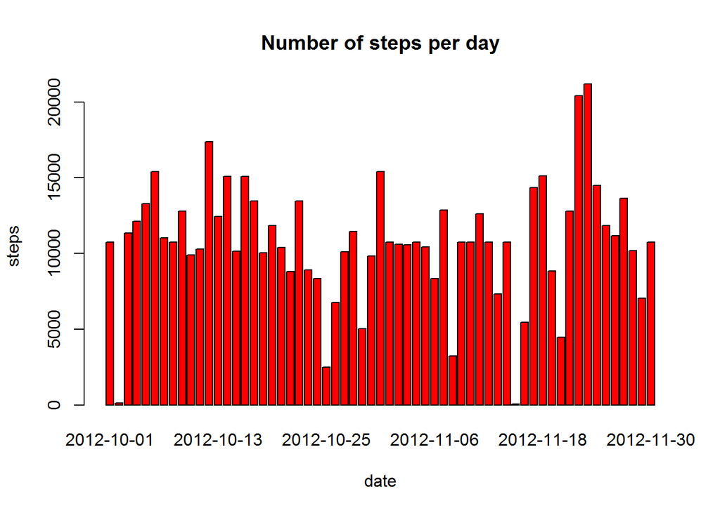

```r
activity <-merge(activity,Average_Steps_By_Interval, by = "interval", suffixes =c("",".y"))
nas <-is.na(activity$steps)
activity$steps[nas] <- activity$steps.y[nas]


activity_new <- activity[, c(1:3)]
steps_per_day<-aggregate(steps ~ date, activity_new, sum)
barplot(steps_per_day$steps, names.arg=steps_per_day$date, xlab="date", ylab="steps", main="Number of steps per day", col="red")
```

and Calculate and report the mean and median total number of steps taken per day.

```r
  mean2<-mean(steps_per_day$steps)
```

```r
median2<-median(steps_per_day$steps)
```

Do these values differ from the estimates from the first part of the assignment? What is the impact of imputing missing data on the estimates of the total daily number of steps?

*This histogram is more centralizied and more values show on the average.*

```r
library(lattice)
activity_new$date<-as.Date(activity_new$date,format = '%Y-%m-%d')
activity_new$day <-ifelse(weekdays(activity_new$date) %in%c("Saturday", "Sunday"),'weekend','weekday')
#head(activity_new)

steps_by_interval_and_Daytype<-aggregate(steps~ interval+day,activity_new,FUN="mean")
#head(steps_by_interval_and_Daytype)
```

Make a panel plot containing a time series plot (i.e. type = “l”) of the 5-minute interval (x-axis) and the average number of steps taken, averaged across all weekday days or weekend days (y-axis). The plot should look something like the following, which was creating using simulated data:

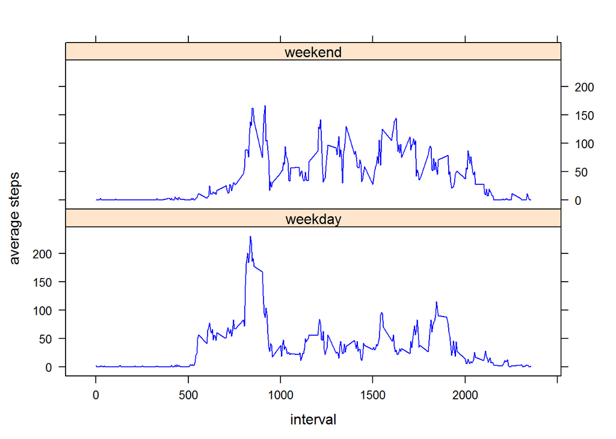

```r
library(lattice)
xyplot(steps ~ interval | day, steps_by_interval_and_Daytype, layout =c(1, 2), type = "l", col="blue", xlab="interval", ylab="average steps")
```

*Are there differences in activity patterns between weekdays and weekends?*

*From the graphs, it appears that there are more activities on the weekends. :> I myself likely to exercise more on weekend too .LOL*